# 1129 HW6-R__Yan Yilin

Question 1: Use R to create the following two matrices and do the indicated matrix multiplication. What is the resulting matrix? (4 points)

```r
# Create the two required matrices
Q1MatrixA <- matrix(c(7,2,9,4,12,13), nrow = 2, ncol = 3)
Q1MatrixB <- matrix(c(1,2,3,7,8,9,12,13,14,19,20,21), nrow = 3, ncol = 4)

# Print the matrices
Q1MatrixA
```

```
     [,1] [,2] [,3]
[1,]    7    9   12
[2,]    2    4   13
```

```r
Q1MatrixB
```

```
     [,1] [,2] [,3] [,4]
[1,]    1    7   12   19
[2,]    2    8   13   20
[3,]    3    9   14   21
```

```r
# Do the indicated matrix multiplication
Q1Result = Q1MatrixA %*% Q1MatrixB
Q1Result
```

```
     [,1] [,2] [,3] [,4]
[1,]   61  229  369  565
[2,]   49  163  258  391
```

The resulting matrix is shown above.

Question 2: (total 13 points) a. Create a data frame like the following table (2 points).

```r
# Create a data frame
Data_Frame <- data.frame (
  id = c(1,2,3,4,5),
  name = c("Peter", "Amy", "Ryan","Gary","Michelle"),
  salary = c(623.3, 515.2, 611.00,729.00, 843.25)
)

# Print the data frame
Data_Frame
```

| id | name | salary |
| --- | --- | --- |
| 1 | Peter | 623.30 |
| 2 | Amy | 515.20 |
| 3 | Ryan | 611.00 |
| 4 | Gary | 729.00 |
| 5 | Michelle | 843.25 |

2. Then add a column of “department”, and assign department names for the 5 persons, for example, IT, finance, computer science, etc., name your own. (2 points).

```r
# Add the "department" column
New_col_DF <- cbind(Data_Frame, department = c("IT","Finance","Accounting","Computer Science","Public Relation"))

#Print the new column
New_col_DF
```

| id | name | salary | department |
| --- | --- | --- | --- |
| 1 | Peter | 623.30 | IT |
| 2 | Amy | 515.20 | Finance |
| 3 | Ryan | 611.00 | Accounting |
| 4 | Gary | 729.00 | Computer Science |
| 5 | Michelle | 843.25 | Public Relation |

3. Extract 1st, 3rd, and 5th rows, with 2nd and 3rd columns, using c function. (3 points).

```r
Extract_result = New_col_DF[c(1,3,5),c(2,3)]
Extract_result
```

|  | name | salary |
| --- | --- | --- |
| 1 | Peter | 623.30 |
| 3 | Ryan | 611.00 |
| 5 | Michelle | 843.25 |

4. plot a bar chart to show the salary of row 1,4,5 and label the bar with people’s name correspondingly. (3 points).

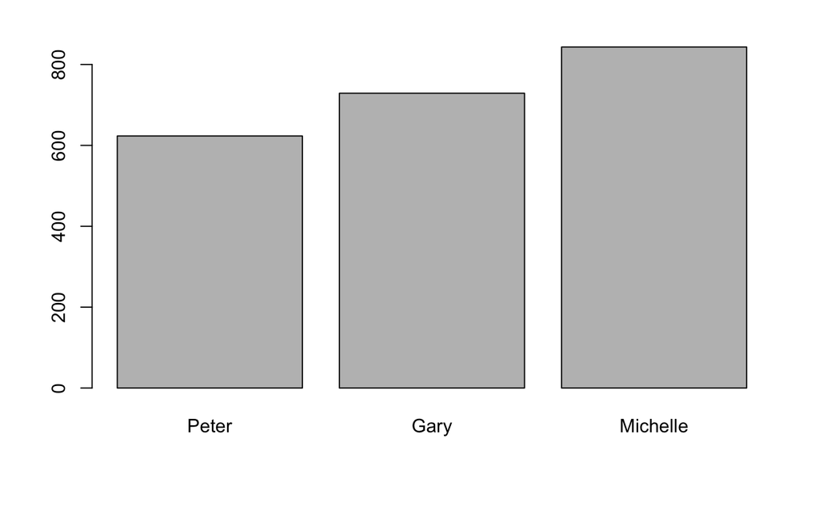

```r
# x-axis values: people's name
x <- New_col_DF[c(1,4,5),c(2)]

# y-axis values: salary
y <- New_col_DF[c(1,4,5),c(3)]

barplot(y, names.arg = x)
```

5. plot a pie chart, based on this data framework, only showing the highest salary, lowest salary, and median salary, give your plot a title, and label each pie. (3 points).

```r
H_S <- max(New_col_DF$salary)
H_L <- min(New_col_DF$salary)
H_M <- median(New_col_DF$salary)
H_S
```

```
[1] 843.25
```

```r
H_L
```

```
[1] 515.2
```

```r
H_M
```

```
[1] 623.3
```

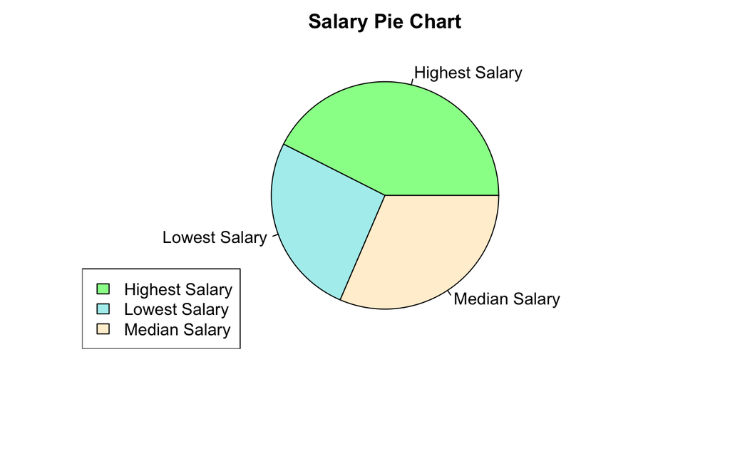

```r
# Create a vector of labels
mylabel <- c("Highest Salary", "Lowest Salary", "Median Salary")

# Create a vector of colors
colors <- c("palegreen", "paleturquoise", "papayawhip")

x <- c(H_S,H_L,H_M)

# Display the pie chart with colors
pie(x, label = mylabel, main = "Salary Pie Chart", col = colors)

# Display the explanation box
legend("bottomleft", mylabel, fill = colors)
```

Question 3: Pick two functions in your final project, transfer that into R programming. One function should involve “if else” (4 points), the other function should involve “for loop or while loop” (4 points). • Test your function, showing your function works. You can assign some values, in order to test the function. • This is individual homework, so you and your team member may pick the same functions but could have different translations. • Note, in your homework submission, paste your python code with your R code for comparison. 1) Transfer one “if else” function:

```r
# Note that by the previous assumptions and settings, ai_win and player_win won't be >2. ai_win or player_win can only be 0,1,2
# So the value assigned here (for the testing purpose) should be numbers from 0,1,2
ai_win = 2
player_win = 1

if (ai_win == 2) {
  print("You LOSE the game since ai has already won 2 rounds.")
} else{
    print("You've won 2 rounds, You WIN the game, Congratulation!!!")
  }
```

```
[1] "You LOSE the game since ai has already won 2 rounds."
```

2. Transfer one “while loop” function:

```r
# by previous setting: replay = input("Play again? (yes/no)")
replay = "noo"

while (replay != "yes" && replay != "no"){
  print("The input is not valid, it should be one of 'yes' or 'no', please retype.")
  replay <- readline(prompt ="Play again? (yes/no)" )
}
```

```
[1] "The input is not valid, it should be one of 'yes' or 'no', please retype."
```

```r
YYYes
```

```
[1] "The input is not valid, it should be one of 'yes' or 'no', please retype."
```

```r
NOOO
```

```
[1] "The input is not valid, it should be one of 'yes' or 'no', please retype."
```

```r
yes
```